# Plot Rivers Inlet Sockeye Salmon State-Space Spawner-Recruitment Model Results

B. Connors

08 December, 2020

# 1 Purpose

The purpose of this document is to summarize spawner-recruitment model output and diagnostics in a unified format for ease of review.

# 2 Basic Convergence Diagnostics

## 2.1 Effective Sample Size

Ideally effective sample sizes are > 400.

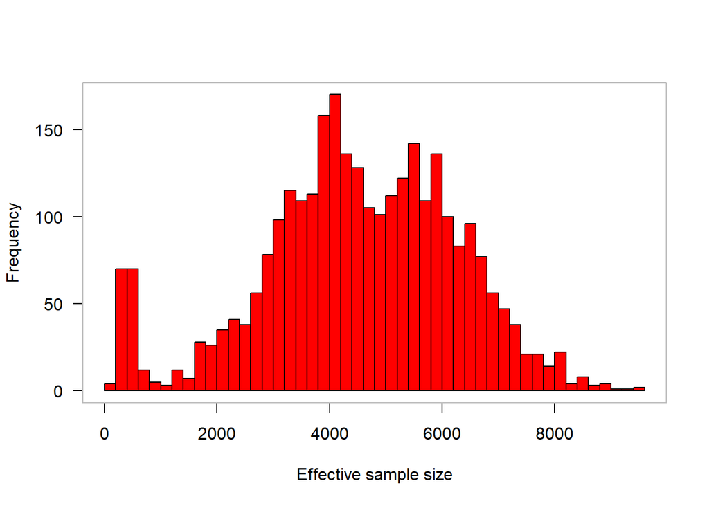

## 2.2 R-hat Convergence Diagnostic

Compares the between- and within-chain estimates for model parameters and other univariate quantities of interest. If chains have not mixed well (i.e., the between- and within-chain estimates don’t agree), R-hat is larger than 1. We recommend running at least four chains by default and only using the sample if R-hat is less than 1.05. Stan reports R-hat which is the maximum of rank normalized split-R-hat and rank normalized folded-split-R-hat, which works for thick tailed distributions and is sensitive also to differences in scale.

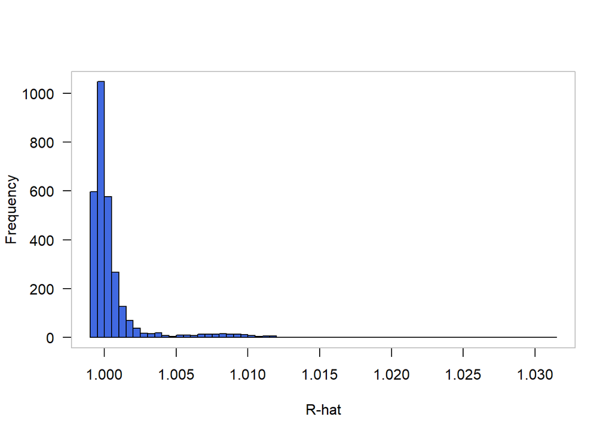

# 3 Key posterior estimates

Biological reference points are in hundreds of thousands and log-normal bias corrected. See `SSSR_AR1_v2.stan` for model details.

|  | mean | 2.5% | 50% | 97.5% | n_eff | Rhat |
| --- | --- | --- | --- | --- | --- | --- |
| lnalpha | 0.39 | 0.06 | 0.37 | 0.80 | 1791 | 1 |
| lnalpha_c | 0.65 | 0.27 | 0.62 | 1.16 | 1399 | 1 |
| beta | 0.05 | 0.01 | 0.05 | 0.09 | 1654 | 1 |
| sigma_R | 0.63 | 0.50 | 0.63 | 0.78 | 3429 | 1 |
| sigma_R0 | 0.79 | 0.38 | 0.71 | 1.58 | 1698 | 1 |
| phi | 0.43 | 0.17 | 0.43 | 0.70 | 1887 | 1 |
| S_max | 29.52 | 11.26 | 21.97 | 77.07 | 1129 | 1 |
| S_eq_c | 15.96 | 8.05 | 13.84 | 30.59 | 1388 | 1 |
| S_msy_c | 4.11 | 0.97 | 3.73 | 7.95 | 1938 | 1 |
| U_msy_c | 0.29 | 0.13 | 0.28 | 0.49 | 1575 | 1 |

# 4 Model Predictions and Fits

## 4.1 Escapement

Observations are blue points and model predictions are median (black line) and 50th and 97.5th intervals

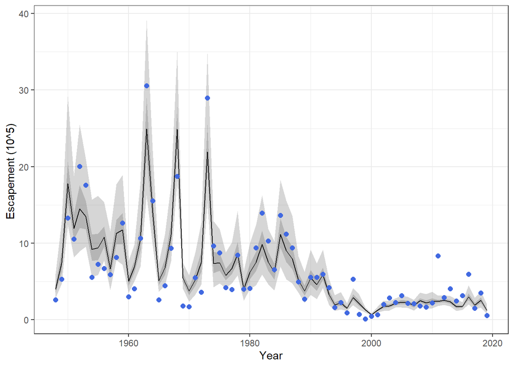

## 4.2 Harvest

Observations are blue points and model predictions are median (black line) and 50th and 97.5th intervals

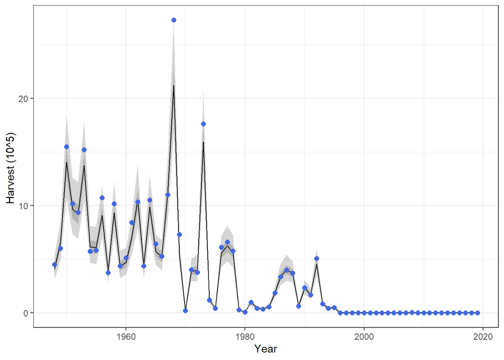

## 4.3 Escapement age composition

Observations are blue points and model predictions are median (black line) and 50th and 97.5th intervals.

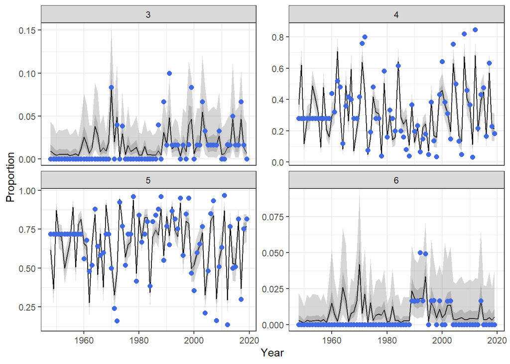

## 4.4 Harvest age composition

Observations are blue points and model predictions are median (black line) and 50th and 97.5th intervals.

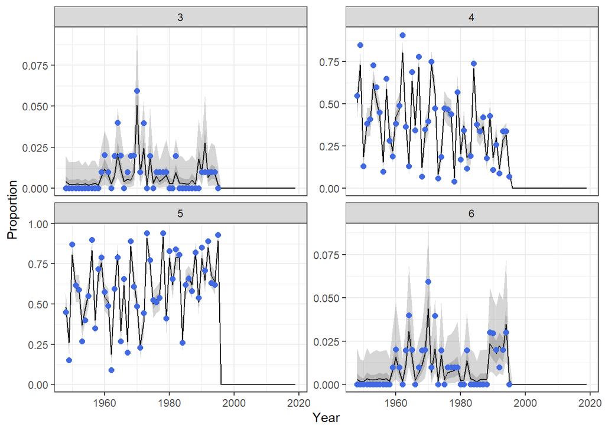

## 4.5 Spawner-recruitment relationship

Predictions are median (black line and points) and 97.5th intervals. Includes recruitment for incomplete brood years at end of time series.

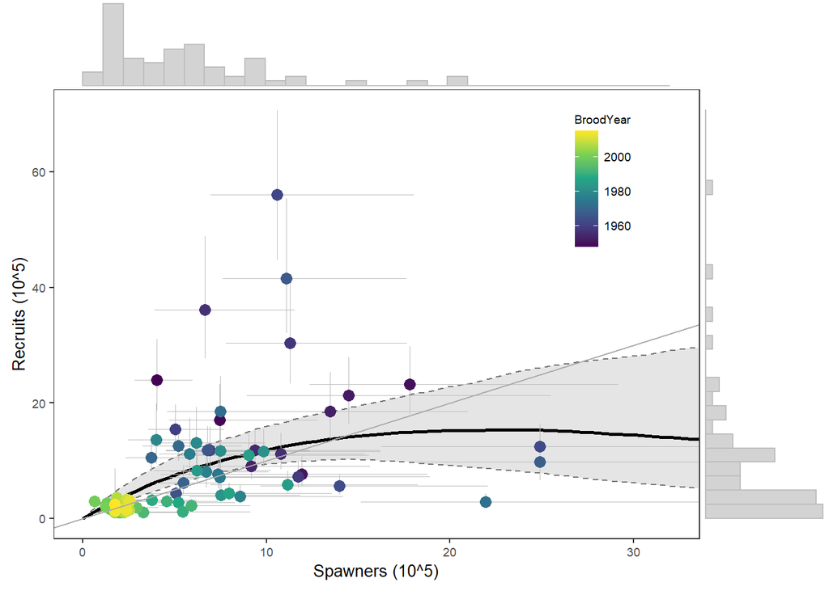

## 4.6 Spawner-recruitment relationship at low spawner abundances

Simply zoomed in on recent period observations.

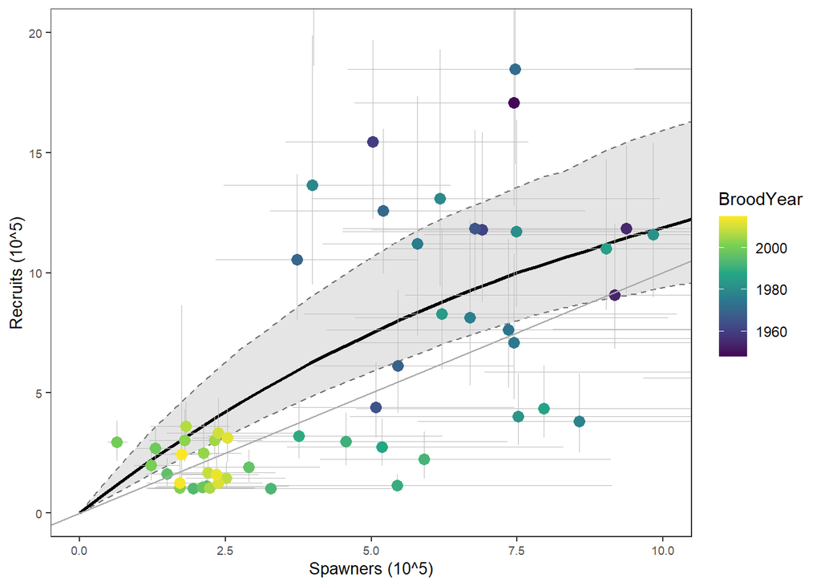

## 4.7 Productivity over time

Predictions are median (black line) and 50th and 97.5th intervals.

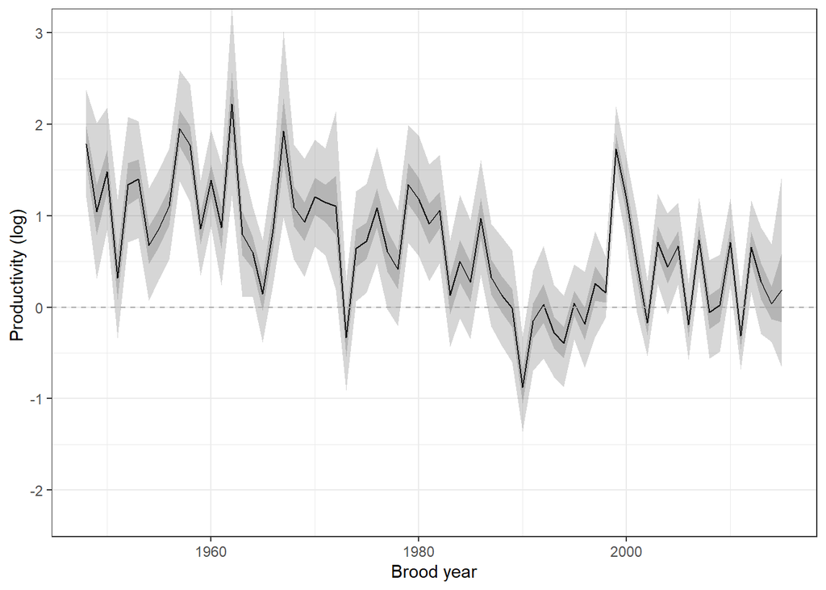

# 5 Biological benchmarks and stock-status.

Summary of stock-recruitment based benchmarks. Lower benchmark is Sgen, upper benchmark is 80% Smsy, both in units of 100,000s.

|  | lower_bm | upper_bm | recent_abund |
| --- | --- | --- | --- |
| 2.5% | 0.4565 | 0.7304 | 1.675 |
| 25% | 1.5987 | 2.3103 | 1.908 |
| 50% | 2.0423 | 3.0419 | 2.042 |
| 75% | 2.6744 | 3.7706 | 2.185 |
| 97.5% | 5.6739 | 7.2984 | 2.480 |

Posterior distribution of stock-recruitment based benchmarks and resnet abundance based on SS-SRA (black) and sonar (light grey).

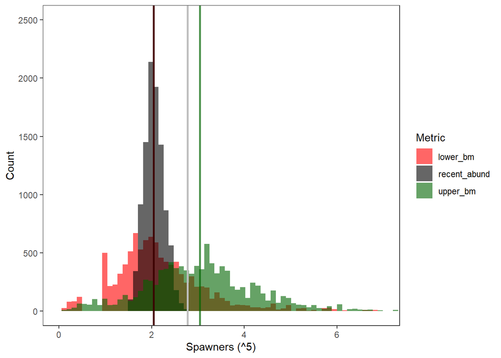

# 6 Extras

Plot of reconstructed spawner abundance based on ratio of clear-stream to sonar estimates for years with data.

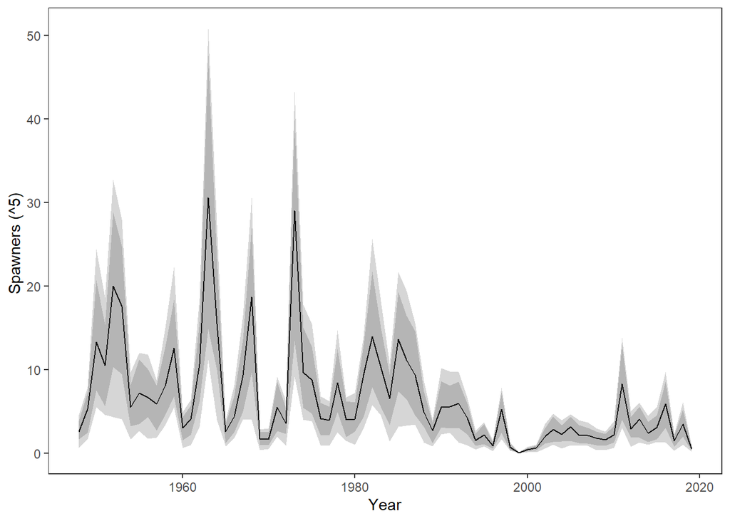

Relationship between clear-stream index and DIDSON counts.

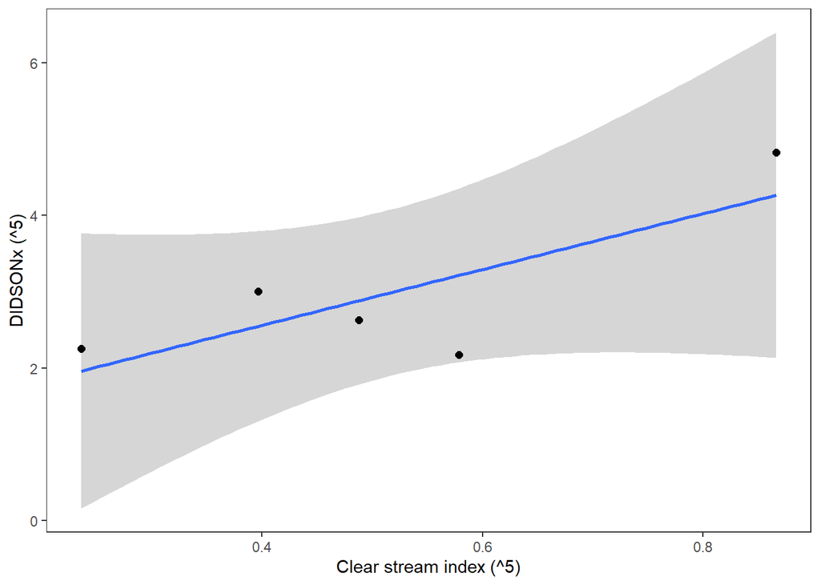

Expanded escapement timeseries with SR benchmarks

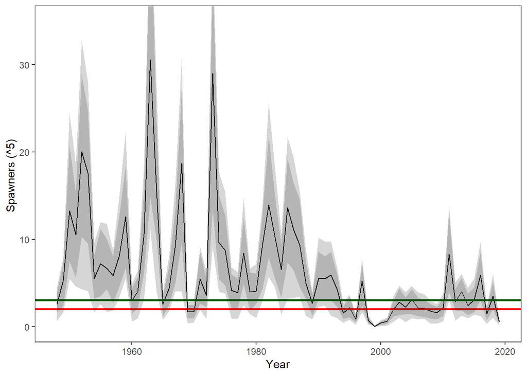

# 7 Model Parameters

Summary of all model parameters.

|  | mean | se_mean | sd | X2.5. | X25. | X50. | X75. | X97.5. | n_eff | Rhat |
| --- | --- | --- | --- | --- | --- | --- | --- | --- | --- | --- |
| lnR[1] | 2.2985 | 0.0182 | 0.8166 | 0.4909 | 1.8052 | 2.3648 | 2.8478 | 3.7232 | 2003.6 | 1.0015 |
| lnR[2] | 1.9624 | 0.0037 | 0.2289 | 1.5322 | 1.8030 | 1.9574 | 2.1106 | 2.4209 | 3769.1 | 1.0012 |
| lnR[3] | 2.1318 | 0.0023 | 0.1492 | 1.8386 | 2.0296 | 2.1326 | 2.2359 | 2.4193 | 4157.7 | 0.9998 |
| lnR[4] | 3.6115 | 0.0019 | 0.1346 | 3.3620 | 3.5185 | 3.6041 | 3.7018 | 3.8954 | 5153.2 | 1.0003 |
| lnR[5] | 2.9709 | 0.0019 | 0.1448 | 2.6854 | 2.8754 | 2.9722 | 3.0685 | 3.2504 | 5920.1 | 0.9999 |
| lnR[6] | 3.1492 | 0.0024 | 0.1580 | 2.8574 | 3.0414 | 3.1410 | 3.2483 | 3.4676 | 4166.8 | 1.0000 |
| lnR[7] | 3.0013 | 0.0021 | 0.1464 | 2.7183 | 2.9044 | 2.9995 | 3.0949 | 3.2976 | 4745.9 | 1.0013 |
| lnR[8] | 3.1765 | 0.0018 | 0.1316 | 2.9238 | 3.0834 | 3.1773 | 3.2657 | 3.4357 | 5340.0 | 0.9998 |
| lnR[9] | 2.8389 | 0.0023 | 0.1501 | 2.5493 | 2.7361 | 2.8386 | 2.9383 | 3.1445 | 4206.3 | 0.9999 |
| lnR[10] | 3.1478 | 0.0016 | 0.1268 | 2.8925 | 3.0640 | 3.1472 | 3.2316 | 3.3974 | 6634.8 | 0.9995 |
| lnR[11] | 2.0352 | 0.0025 | 0.1705 | 1.7026 | 1.9209 | 2.0365 | 2.1473 | 2.3724 | 4488.3 | 0.9999 |
| lnR[12] | 3.0600 | 0.0020 | 0.1362 | 2.7958 | 2.9664 | 3.0601 | 3.1507 | 3.3289 | 4739.7 | 0.9997 |
| lnR[13] | 2.9207 | 0.0025 | 0.1560 | 2.6220 | 2.8140 | 2.9183 | 3.0256 | 3.2334 | 4007.1 | 0.9999 |
| lnR[14] | 2.2042 | 0.0020 | 0.1452 | 1.9237 | 2.1061 | 2.2059 | 2.3015 | 2.4884 | 5030.9 | 0.9998 |
| lnR[15] | 2.4741 | 0.0018 | 0.1303 | 2.2156 | 2.3882 | 2.4731 | 2.5620 | 2.7289 | 5262.5 | 1.0015 |
| lnR[16] | 2.4192 | 0.0018 | 0.1402 | 2.1460 | 2.3261 | 2.4183 | 2.5131 | 2.6949 | 6237.0 | 1.0003 |
| lnR[17] | 3.5920 | 0.0026 | 0.1456 | 3.3200 | 3.4895 | 3.5859 | 3.6879 | 3.8887 | 3097.5 | 0.9997 |
| lnR[18] | 3.4129 | 0.0022 | 0.1396 | 3.1497 | 3.3166 | 3.4119 | 3.5017 | 3.7055 | 3905.2 | 1.0000 |
| lnR[19] | 1.9837 | 0.0020 | 0.1554 | 1.6762 | 1.8787 | 1.9853 | 2.0869 | 2.2912 | 5960.2 | 0.9998 |
| lnR[20] | 2.7387 | 0.0017 | 0.1205 | 2.5033 | 2.6585 | 2.7376 | 2.8178 | 2.9799 | 5100.8 | 0.9999 |
| lnR[21] | 2.4694 | 0.0020 | 0.1478 | 2.1721 | 2.3739 | 2.4675 | 2.5675 | 2.7622 | 5735.8 | 0.9998 |
| lnR[22] | 4.0277 | 0.0018 | 0.1144 | 3.8021 | 3.9521 | 4.0268 | 4.1010 | 4.2584 | 4097.6 | 1.0002 |
| lnR[23] | 2.5226 | 0.0018 | 0.1390 | 2.2492 | 2.4282 | 2.5238 | 2.6168 | 2.7950 | 6244.4 | 0.9993 |
| lnR[24] | 1.7254 | 0.0024 | 0.1560 | 1.4161 | 1.6214 | 1.7258 | 1.8330 | 2.0273 | 4220.4 | 0.9998 |
| lnR[25] | 1.4825 | 0.0030 | 0.1752 | 1.1410 | 1.3664 | 1.4822 | 1.5967 | 1.8380 | 3462.5 | 1.0001 |
| lnR[26] | 2.4777 | 0.0021 | 0.1425 | 2.2106 | 2.3795 | 2.4733 | 2.5686 | 2.7697 | 4510.7 | 1.0003 |
| lnR[27] | 3.7314 | 0.0022 | 0.1394 | 3.4684 | 3.6365 | 3.7282 | 3.8267 | 4.0151 | 4002.7 | 1.0003 |
| lnR[28] | 2.2859 | 0.0034 | 0.2090 | 1.8931 | 2.1399 | 2.2835 | 2.4226 | 2.7001 | 3787.9 | 1.0002 |
| lnR[29] | 1.8168 | 0.0038 | 0.2053 | 1.4263 | 1.6751 | 1.8144 | 1.9552 | 2.2291 | 2925.0 | 1.0015 |
| lnR[30] | 2.3572 | 0.0023 | 0.1444 | 2.0853 | 2.2577 | 2.3559 | 2.4519 | 2.6479 | 3816.1 | 1.0006 |

[output cut: 2925 more lines]